### *Ranking American Universities: A Values-Driven Approach*

Jeremy Cohen | May 1, 2016

**CONTENTS**

Introduction

Data Sources & Preparation

Initial Exploration

Note on Violent Crime

Analysis: Comparing Ranking Systems

Conclusion

Appendices

Prepared for Professor Linda Zhao’s course in Modern Data Mining (Stat 471, University of Pennsylvania, Spring 2016) and submitted as its final assignment. The author wishes to express his gratitude for the instructor’s (and assistants’) guidance and patience throughout the semester.

### Introduction

University ranking systems are widespread and widely accepted as useful indicators of higher-education value. International lists gravitate toward the United Kingdom’s Oxbridge and American technology institutes ; in the U.S., the most famous ranking body, U.S. News and World Report, garners such demand that it charges a $30 annual subscription service for the full version of its considerations. Global university rankings reflect a number of implicit assumptions about education-related values and arguably influence admissions policies for many schools.

Most of these ranking systems rely heavily on admissions selectivity, admissions yield (how many of those admitted enroll), test scores of enrolled students, and research output of faculty. These heuristics obviously privilege those elite institutions with high volume of applicants and high standards for faculty research-that is, the Ivy League and similar.

This project proposes to consider instead two classification regimes concerned with service-learning and community engagement, a “broader mission” of higher-education institutions. In particular, the study will an exploration and analysis of the Community Engagement classification system (Carnegie Foundation for the Advancement of Teaching, now maintained by the New England Resource Center for Higher Education) and the Service rankings by the Washington Monthly.

**Motivation**

The University of Pennsylvania was the first Ivy League school on the Carnegie Foundation’s published list. (Cornell was classified in 2010.) After some cursory examination of the most recent list, most of the recognized institutions are (a) public and state-affiliated, either land-grant flagship or satellite campuses; (b) small, private, and often wealthy liberal-arts schools; or larger schools in urban settings. Penn is also the highest-ranked Ivy for Service in the Washington Monthly list (at 61st, just above Dartmouth). Overall, neither regime aligns with U.S. News and World Report’s, indicating that the “best” universities may not be doing the most good.

Why does Penn qualify as a (moderate) exception to the rule? What factors influence a university’s community engagement programming, classification, and rank? Copious data is available from the Department of Education’s College Scorecard, its Campus Safety and Security Data Analysis Cutting Tool, and the Carnegie Classification of Institutions of Higher Education.

A personal impetus for this project stems from my enrollment and interest in a course last semester on Urban University-Community Relations, focusing especially on Penn’s complicated past in West Philadelphia and the future of so-called Academically-Based Community Service (ABCS) courses.

**Hypothesis**

Those universities score better if located in urban environments (perhaps higher crime rates), with larger proportions of low-income, first-generation, and minority students, and with more students majoring in non-business fields, especially social policy or education. The primary goal is to understand principal components underlying community-engagement recognition; the secondary motivation is to create an effective classifier modeling inclusion in the Carnegie Foundation’s list (0 or 1) and to find under- and over-performers compared to the Washington Monthly rankings. Is Penn’s commitment to community engagement above the curve, in line with reasonable expectations?

### Data Sources & Preparation

*Carnegie Community Engagement classification:* The Carnegie foundation has classified 361 American higher-education institutions of various features as committed to community engagement, operationally and curricularly.

“Community engagement describes collaboration between institutions of higher education and their larger communities (local, regional/state, national, global) for the mutually beneficial exchange of knowledge and resources in a context of partnership and reciprocity.

“The purpose of community engagement is the partnership of college and university knowledge and resources with those of the public and private sectors to enrich scholarship, research, and creative activity; enhance curriculum, teaching and learning; prepare educated, engaged citizens; strengthen democratic values and civic responsibility; address critical societal issues; and contribute to the public good.”

More information is available on the [NERCHE website](http://nerche.org/index.php?option=com_content&view=article&id=341&Itemid=92). There are understandable problems with the data – the classification is voluntarily pursued by colleges and universities, not as an award but as a step toward institutional progress. (Still, we might presume that a college which does not pursue Carnegie recognition would not qualify for high levels of engagement.)

*Washington Monthly:* The mission of the ranking system is explained on [the website](http://www.washingtonmonthly.com/college_guide/toc_2015.php): “Unlike U.S. News and World Report and similar guides, this one asks not what colleges can do for you, but what colleges are doing for the country. Are they educating low-income students, or just catering to the affluent? Are they improving the quality of their teaching, or ducking accountability for it? Are they trying to become more productive-and if so, why is average tuition rising faster than health care costs? Every year we lavish billions of tax dollars and other public benefits on institutions of higher learning. This guide asks: Are we getting the most for our money?” Specifically, the Washington Monthly considers the following to develop “Service” rankings for 283 U.S. institutions: Peace Corps and ROTC involvements (rank); federal work-study funds spent on service; community service participation and hours served (rank); and service-related and financial aid resources (rank). While the service-exclusive rankings are not published explicitly, the website’s sorting tool allows for implicit ordering before downloading as an Excel sheet. A full list of variables and descriptions is available in the appendix.

*The Campus Safety and Security Data Analysis Cutting Tool:* Data from all postsecondary institutions, for all on-campus and noncampus violent crimes, summed across 2013 and 2014 but excluding non-forcible sexual crimes (incest, statutory rape). From [the website](http://ope.ed.gov/security/), run by the Dept. of Education: “The data are drawn from the OPE Campus Safety and Security Statistics website database to which crime statistics and fire statistics (as of the 2010 data collection) are submitted annually, via a web-based data collection, by all postsecondary institutions that receive Title IV funding (i.e., those that participate in federal student aid programs).”

*Carnegie Classifications & Dept. of Education College Scorecard:* Fully described in its Appendix, this data (provided by the [Dept. of Education](https://collegescorecard.ed.gov/data/) and curated by [Carnegie Classifications of Institutes of Higher Education](http://carnegieclassifications.iu.edu/downloads/CCIHE2015-FactsFigures-01Feb16.pdf)) includes a wide variety of publically accessible information, most of which classifies schools by location, size, tuition, research level, et al.

A good deal of data cleaning was required. This represented the brunt of time which the author spent on the project, in fact. All data was labeled and sorted by the Department of Education’s “unitid” unique identifiers. Original and “clean” spreadsheets have been included in the final submission.

### Initial Exploration

Which colleges are the focus of this study? Those which had (publicly available) rankings in US News and World Report, were featured in the Washington Monthly’s alternative rankings, and for which crime data was available from the Department of Education. All told, 182 schools qualify, a list that includes all eight Ivy League institutions and most other recognizable names.

*Nationwide Distribution*

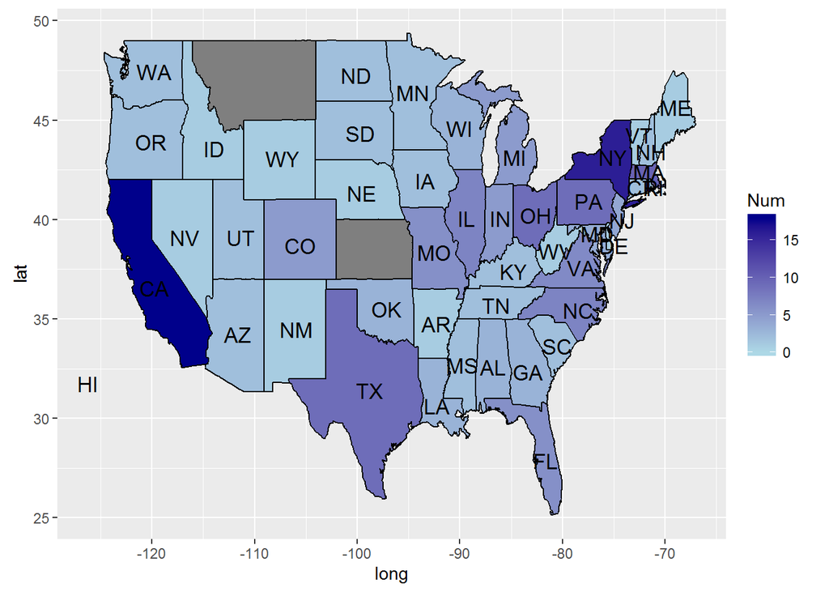

A plurality of institutions represent California, New York, Massachusetts, Texas, Pennsylvania, Ohio, Illinois, and North Carolina. These states include some of the largest and best-educated populations in the Union. Generally, too, the Northeast and Mid-Atlantic regions (along with California) have some of the highest-ranked universities in the nation.

*U.S. News & World Report, Top 50*

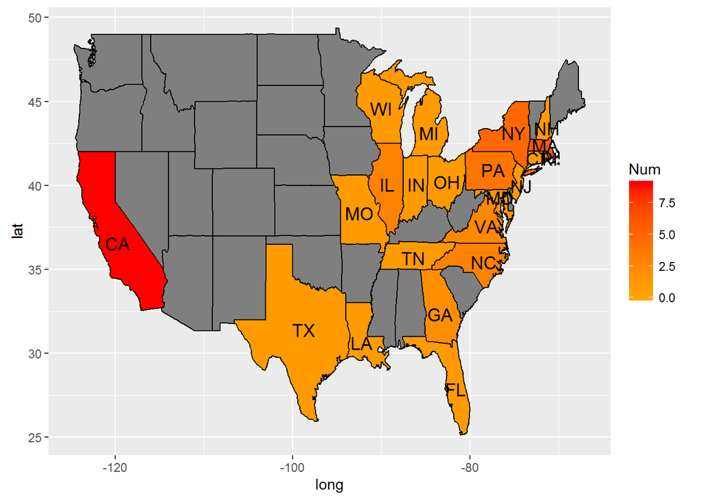

This map offers a glimpse at state “intensity” by including only those universities ranked in the top 50 by U.S. News and World Report. Contrast the distribution here–heavy along the coasts, with only Illinois among the inland states having more than one top-50 university–to the rather more even spread when colleges are ranked or classified by community engagement.

*Washington Monthly, Top 50 Overall*

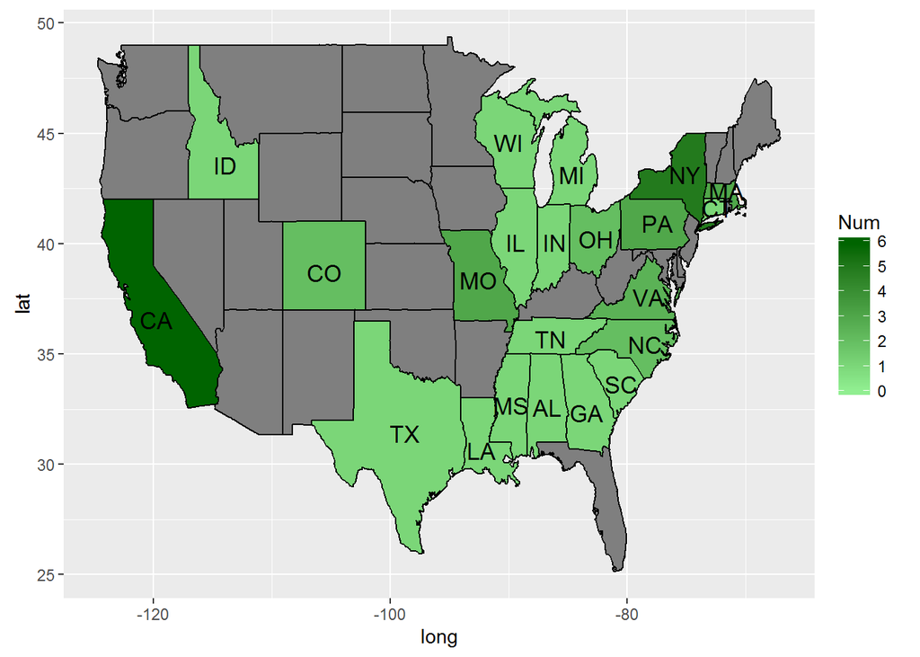

*Carnegie Classified, Community Engagement*

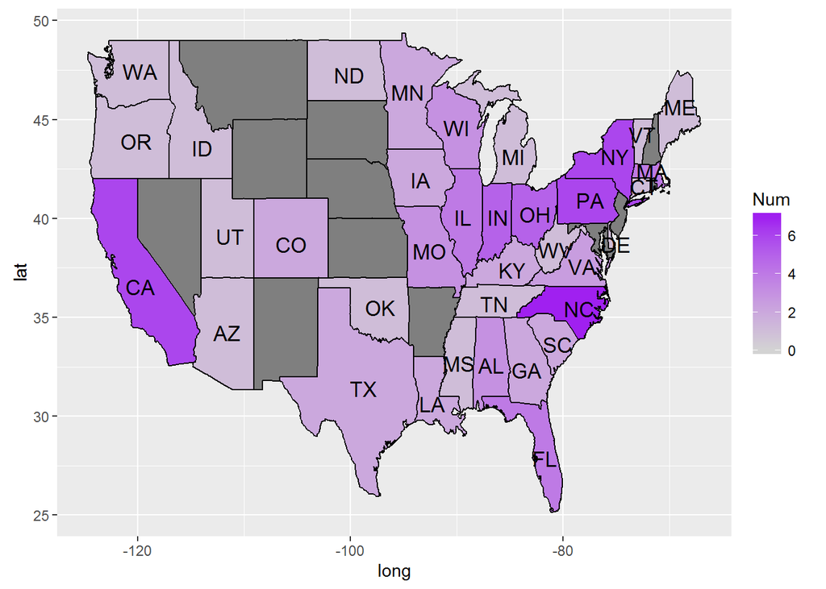

The Carnegie Foundation classification system recognizes schools for their curricular and programmatic commitments to community engagement. (In 2006 and 2008, a school could apply for *one* of academic or operational recognition, but the Foundation has since required both of all successful designees.) As it happens, Carnegie recognizes almost exactly half of the schools common to US News, Washington Monthly, and the Dept. of Education’s crime figures.

| Carnegie | Freq |
| --- | --- |
| FALSE | 92 |
| TRUE | 90 |

As a proof of concept, the Washington Times’ service-specific rankings *do* line up with the Carnegie Foundation’s classification, insofar as the service rankings are a significant predictor for classification in logistic regression.

|  | Estimate | Std. Error | z value | Pr(>\|z\|) |
| --- | --- | --- | --- | --- |
| (Intercept) | 0.8114 | 0.2934 | 2.7653 | 0.0057 |
| washington.service.rank | -0.0071 | 0.0021 | -3.3059 | 0.0009 |

### Note on Violent Crime

Penn’s optimistic engagement with its West Philadelphia community began in earnest after high rates of oncampus and off-campus crime during the 1980’s and 1990’s. Violent crime incidence on university campuses therefore seems a potentially significant feature when predicting a school’s institutional motivation to engage with its community.

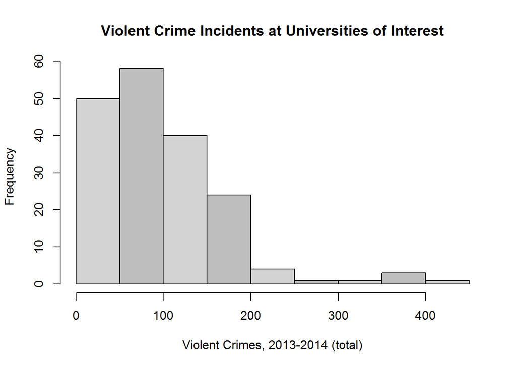

Violent crime incidents are skewed away from high volume, which occurs only at a few select universities. It had been my original hypothesis that violent crime would be associated with service ranking:

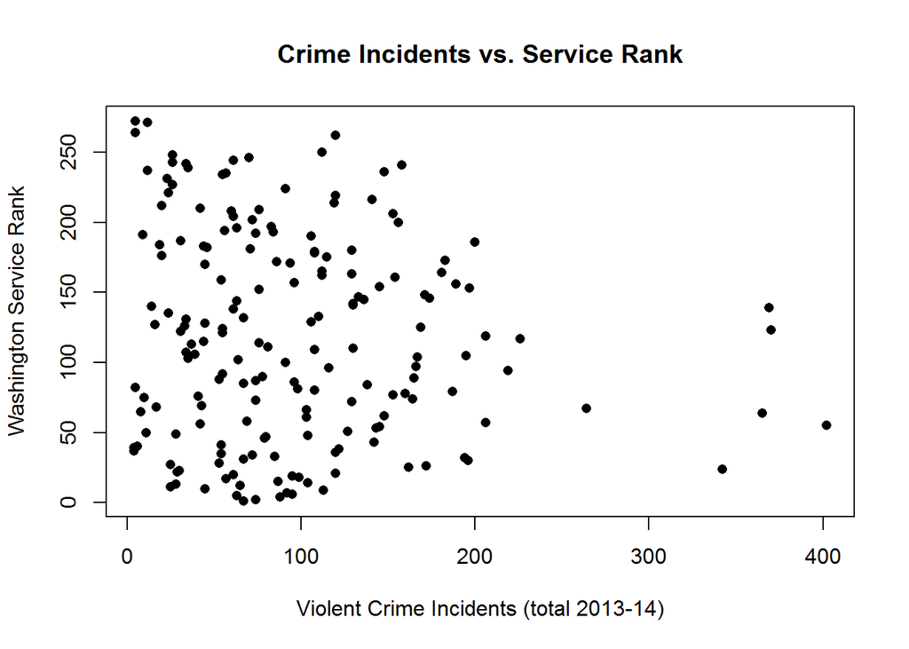

|  | Violent.Crime |
| --- | --- |
| Service.Rank | -0.1168526 |

The correlation between the variables is quite low. After regressing with the Carnegie classifications to find any explanatory validity:

|  | Estimate | Std. Error | z value | Pr(>\|z\|) |
| --- | --- | --- | --- | --- |
| (Intercept) | -0.3607717 | 0.2535809 | -1.422708 | 0.1548207 |
| violent | 0.0035366 | 0.0021609 | 1.636618 | 0.1017103 |

Violence is not significant at the 0.05 or 0.01 levels, but it is close to the 0.10 level, and its coefficient is positive – so higher incidence of violent crime is positively associated with a higher likelihood of community-engagement classification. The difficulty of this particular thread in the broader analysis is a historical component: it takes years (if not decades) for slow-moving higher-education institutions to implement initiatives. Perhaps crime data from 10 or 20 years ago would be a more illuminating indication.

In the meantime, I will leave violent crime indidence among the explanatory variables (predictors) during the rest of the analysis, in case it should prove significant.

### Analysis: Comparing Ranking Systems

Having examined the state-by-state distribution of schools satisfying the different ranking priorities, a reasonable next step is cursory examination of the ranking data themselves. The U.S. News & World Report regime is skewed toward lower scores, since only a handful of institutions satisfy all of the integral considerations.

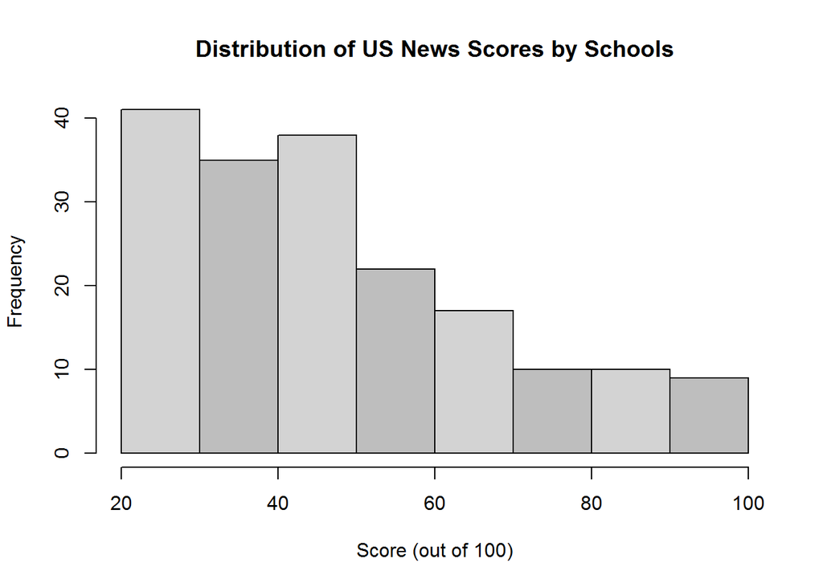

The distribution of total scores for the top 50 ranked schools is almost flat, with indications in the 35-50 ranks that most schools will be concentrated in the 40-60 range.

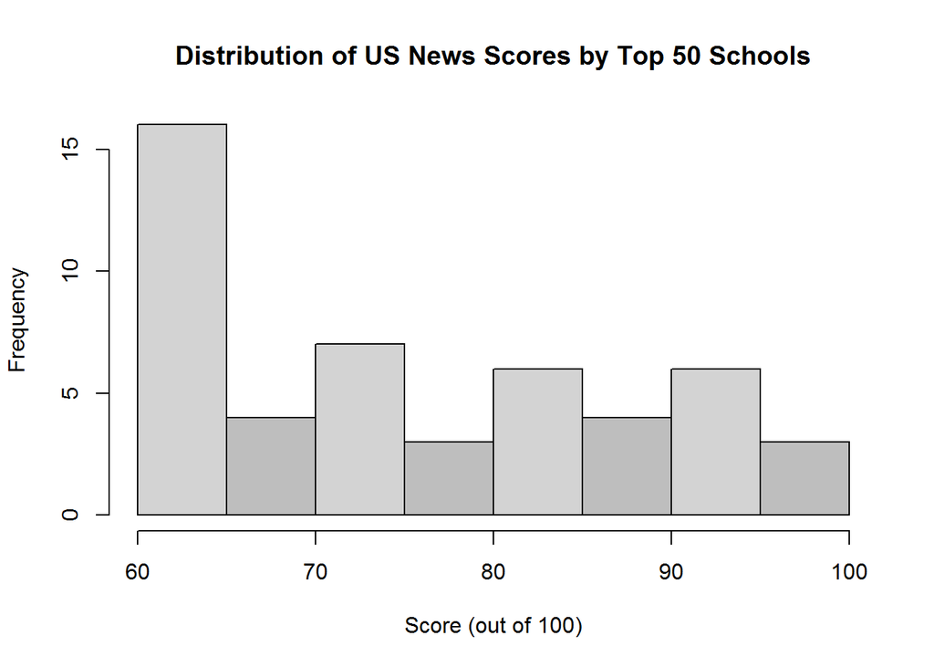

Quantifying these distributions exactly, the median score for all ranked schools (considered in this sample) is slightly below 50, and that of the top 50 schools is slightly below 75. But we can assume a reasonably standard distribution, where the top quartile inhabits the top quartile of scores.

|  | mean | median | s.d. |
| --- | --- | --- | --- |
| all | 48.24 | 44.5 | 20.25 |
| top50 | 75.80 | 74.0 | 12.99 |

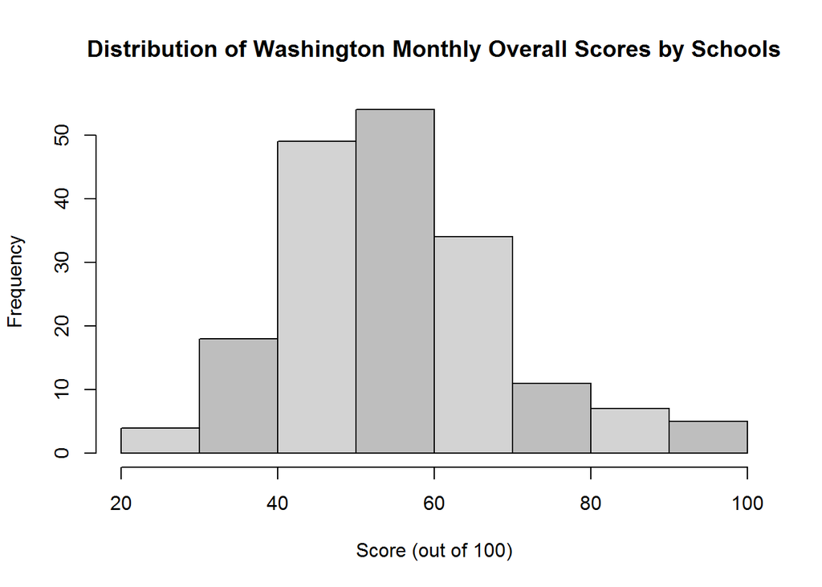

|  | mean | median | s.d. |
| --- | --- | --- | --- |
| all | 55.37 | 53.5 | 14.29 |
| top50 | 75.76 | 71.0 | 9.82 |

The similarities of distribution – same scale, analogous means and deviations – allows for effective and intuitive comparison without too much standardization.

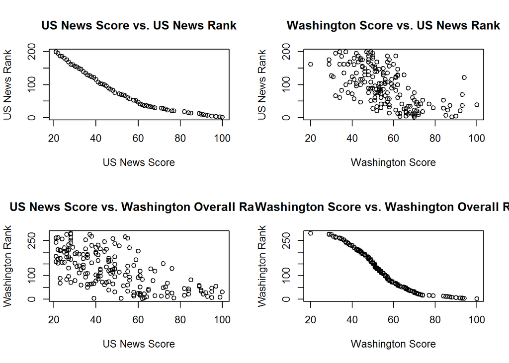

The two diagonal graphs are straightforward enough, representing the (roughly) linear relationship between each ranking system’s score values and final ranks for all schools. The other two graphs attempt to explain a ranking system using the other system’s score values. In both cases, the relationship appears more linear (more highly correlated) than one might expect, given the Washington Monthly’s stated goals of using alternative scoring metrics. The correlations are in the table below, with negative values because rank and score are inversely proportional.

|  | US.Score | Wash.Score |
| --- | --- | --- |
| US.Rank | -0.9579606 | -0.6365731 |
| Wash.Rank | -0.6135689 | -0.9452282 |

There is far less of a linear relationship (and a much lower correlation) when the Washington Monthly’s rank is on the basis of “Service” considerations alone. The Washington overall score is only correlated with the service rank at 0.51, even though the latter is one of three primary considerations in the determination of the former. The U.S. News score value has almost no explanatory power with regard to how a school performs in this weighted basket of metrics.

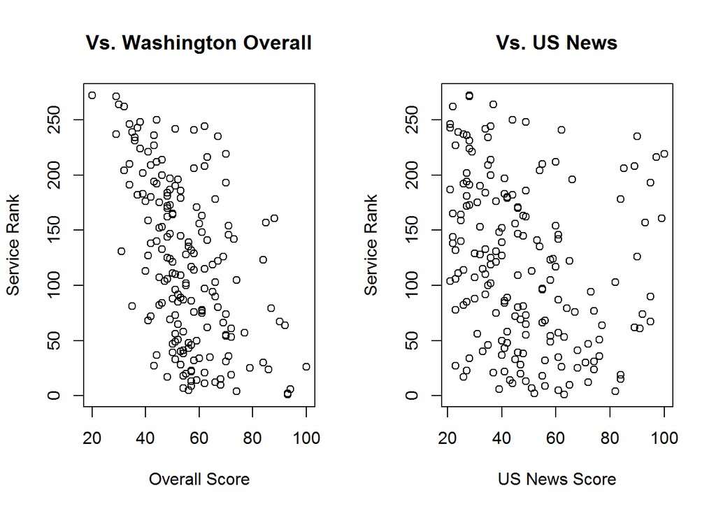

|  | Wash.Score | US.Score |
| --- | --- | --- |
| Serv.Rank | -0.5099944 | -0.245224 |

Putting the picture together, and comparing the US News and Washington Monthly’s *service* ranking systems explicitly:

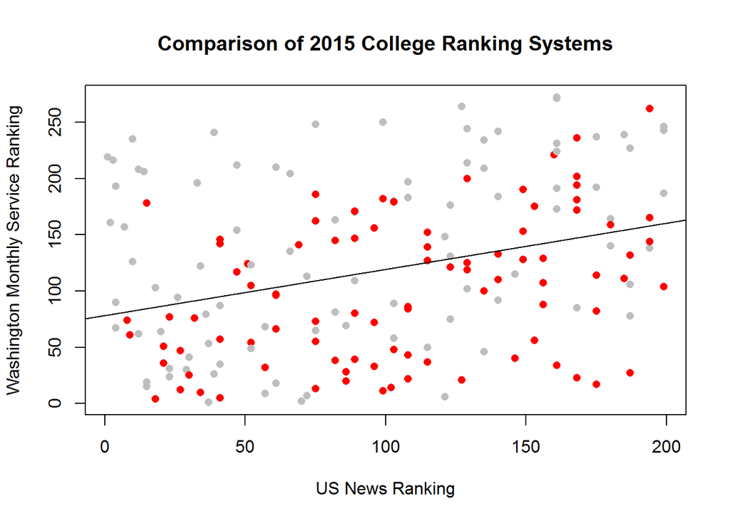

|  | US.News.Rank |
| --- | --- |
| Service.Rank | 0.32 |

The correlation is quite low. Additionally, data points have been colored according to their Carnegie community-service classification, with red indicating “classified” and grey indicating “not classified”. There does not appear to be an obvious relationship between the horizontal axis and the classifications, and it is too difficult to tell from the eye if the vertical axis provides a better approach.

As a proof of concept, the Washington Times’ service-specific rankings *do* line up with the Carnegie Foundation’s classification, with a linear-model coefficient at a higher level of significance than either the Washington overall rankings or the US News score.

|  | Estimate | Std. Error | z value | Pr(>\|z\|) |
| --- | --- | --- | --- | --- |
| (Intercept) | 3.2441 | 1.0005 | 3.2425 | 0.0012 |
| washington.service.rank | -0.0109 | 0.0027 | -3.9472 | 0.0001 |
| washington.overall.score | -0.0135 | 0.0161 | -0.8388 | 0.4016 |
| usnewsscore | -0.0262 | 0.0108 | -2.4223 | 0.0154 |

That said, it is surprising (given the hypotheses thus far) that US News score is so significant in explaining Carnegie community-engagement classification.

Since the Washington Monthly’s “service” ranking is a composite of metrics, it might be worth asking Which service-specific components of the Washington Monthly report are most closely associated with the Carnegie classifier rule.

|  | AIC | BIC |
| --- | --- | --- |
| basket | 230.6856 | 249.9096 |
| all | 213.7583 | 261.8184 |
| signif | 201.8581 | 217.8781 |

It seems that the best model for predicting Carnegie classification, using only the Washington Monthly’s metrics, includes federal funding of service-based work-study jobs (positive coefficient) and institutional support (staff, courses, financial aid) for service programs (slightly negative coefficient, but inversely proportional because rank). Also, a university’s number of awarded science and engineering PhD’s is correlated (positive, with a tiny coefficient) and the percentage of its faculty which belongs to national professional- or research-oriented academies (highly negative). That is, a school with a better (lower) rank for institutional service support and more federal funding for work-study service is more likely to be classified by the Carnegie system. A school with a better (lower) rank for STEM doctorates and a higher percentage of successful researchers among its faculty is markedly less likely to be classified by the Carnegie system.

The Washington Monthly’s overall rankings include faculty’s academy membership as *positive* components of a university’s overall score and rank, since this should indicate a more sophisticated institution with higher-quality research opportunities. While it is a clear indication of a tier-one research university (e.g. the University of Pennsylvania, or any Ivy League member), there appears to be a trade-off in terms of service-learning orientation.

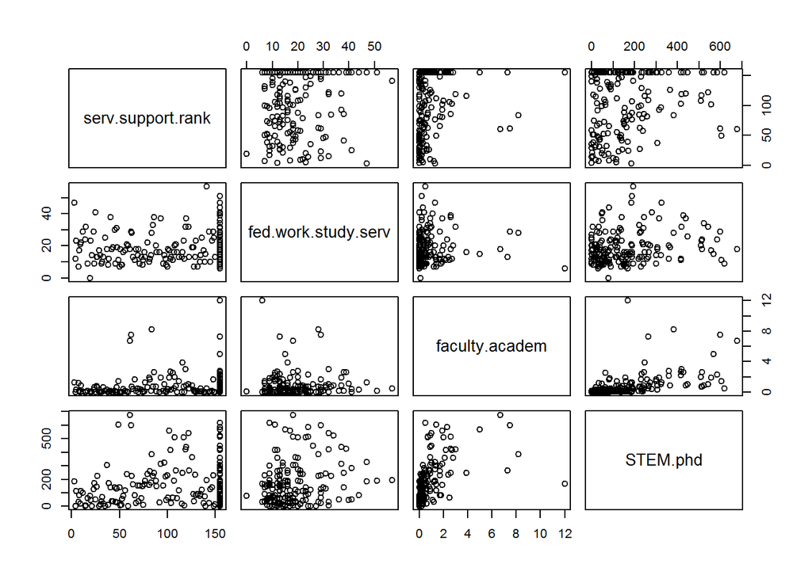

The relationships are not obviously linear, but general trends exist indicating negative correlations between institutional support for service and institutional support for research (especially in STEM fields). Ranks are inversely proportional, since “lower” means “better”.

|  | serv.support.rank | fed.work.study.serv | faculty.academ | STEM.phd |
| --- | --- | --- | --- | --- |
| serv.support.rank | 1.0000000 | 0.0332850 | 0.0907760 | 0.1563684 |
| fed.work.study.serv | 0.0332850 | 1.0000000 | 0.0457053 | 0.1934056 |
| faculty.academ | 0.0907760 | 0.0457053 | 1.0000000 | 0.5218233 |
| STEM.phd | 0.1563684 | 0.1934056 | 0.5218233 | 1.0000000 |

The only quantitatively significant correlation is that between number of science & engineering PhD’s awarded and percentage of faculty belonging to academies, at approximately 0.52. Given that the former is associated positively (if minutely) with Carnegie classification and the latter is associated negatively (significantly), it seems that they do not collectively correspond to some larger feature (i.e. principal component) about universities which could influence its community-engagement classification.

*Testing the Model*

Of these, 94 are complete cases (no NA entries).

There’s a risk that the schools included by the Washington rankings but excluded by U.S. News and World Report and Dept. of Ed crime data are not significant enough to warrant Carnegie classification. But there are 361 classified institutions, and we can check the breakdown for the Washington testing data:

| Carnegie | Freq |
| --- | --- |
| FALSE | 52 |
| TRUE | 42 |

While this isn’t quite the clean 50-50 split of the training (common) observations, there are a sufficient number of both types to justify a test of prediction error. There is no obvious “cost” to mis-classifying a university as service-oriented when the Carnegie Foundation would disagree, or vice versa, other than a potentially unhappy student matriculant – either because the undergraduate “missed out” on service-learning or because they were forced into required courses or programs of little interest. (At which point, the cost may well be some portion of tuition.) Given no preferable risk ratio, and knowing ex ante that 42/94 (top 45%) will be classified “true”, we will use as threshold the 55th percentile of each model’s predicted probabilities.

|  | AIC | BIC | MCE |
| --- | --- | --- | --- |
| basket | 230.6856 | 249.9096 | 0.3617021 |
| all | 213.7583 | 261.8184 | 0.3510638 |
| signif | 201.8581 | 217.8781 | 0.2659574 |

Unsurprisingly, the model using only signficant variables performs best. The greedy model has a slightly better mis-classification error than the sparser, basket-derived approach, but even so the third fit outperforms on both the training classifiers (AIC, BIC) and in testing error.

**PRINCIPAL FACTORS FOR RESPONSE VARIABLES**

Moving beyond the information already included in our ranking systems, there is a vast panoply of available data on U.S. colleges. The Carnegie Foundation also curates (from the Dept. of Education’s stores) entries for some of the more important variables.

*Quantitative Response Variables: LASSO*

Since we have tons of variables (detailed in the Appendices), it makes sense to begin with LASSO. This is a powerful statistical approach that deals with a large number of possible predictors (many-dimensional space) via a penalty value (lambda), forcing smaller coefficients toward zero, until a sufficiently sparse set of predictors remains. These variables can become the basis for a more plausible (nonzero degrees of freedom) logistic regression.

Let us begin with U.S. News and World Report Rankings. After covarying across multiple folds and calculating the mean-squared error, the program returns a plot of error by log(lambda), with indications across the top of how many predictors would remain in the model given the value of lambda. LASSO is a random process, so for the purposes of this report I have implemented set.seed(1).

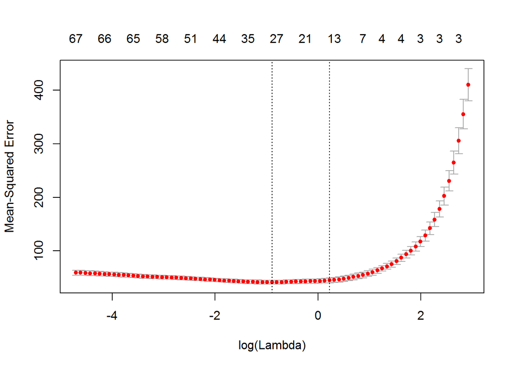

Since we’re more curious about finding the most important factors than about creating a best-possible predictor, we will choose the maximum value of lambda within one standard deviation of the mean-squared error being 0. This corresponds to around 14 variables with nonzero coefficients in our sparse model.

|  | Coefficient |
| --- | --- |
| SECTOR | 2.9806543 |
| ACTCMP25 | 1.4724478 |
| SATACTEQ25 | 0.9007752 |
| IPUG2015 | -0.5731061 |
| CC2000 | -0.2988161 |
| CUSU | -0.1280602 |
| BASIC2005 | -0.1216169 |
| SOCSC_RSD | 0.0832678 |
| SATCMB25 | 0.0384432 |
| STEM_RSD | 0.0082611 |
| HUM_RSD | 0.0073397 |
| violent | 0.0049548 |
| UGNTRPT14 | -0.0047665 |
| CONTROL | 0.0000000 |

If we were interested in building rigorous predictors (while also avoiding overfitting), we would pass these variables through a linear model, remove those predictors above a given significance threshold, and then use the final regression equation as a predictor for testing data. As it is, we are more curious about *which* variables are significant factors in a ranking system, either because of conscious (or implicit) inclusion by the ranking body or because of a correlation due to lurking variables. Positive coefficients indicate a positive association, such that an increase in the variable’s value predicts an increase in the response variable; negative coefficients indicate the opposite.

The function I have written provides a quick list of the sparse LASSO model (lambda.1se), sorted by coefficient magnitude (absolute value). The above table includes predictors with nonzero coefficients predictive of U.S. News & World Report scores. An immediate surprise is that violent crime incidence is associated *positively* (however insignificantly) with a school’s U.S. News score.

*Washington Monthly (overall) scores:*

|  | Coefficient |
| --- | --- |
| IPUG2015 | -0.7233655 |
| BASIC2010 | -0.4758312 |
| BASIC2005 | -0.4671099 |
| ACTCMP25 | 0.4507968 |
| STEM_RSD | 0.0532638 |

*Washington Monthly service ranks:*

In some iterations, the sparsest LASSO fit includes no variables at all, indicating that service ranking is more difficult to predict via the generalist (widely available) university data.

```
##      [,1]
```

Another function, building off the previous, allows us to find predictors which exist in the greedy LASSO models (lambda minimizing error) of two response variables.

|  | Coefficient |
| --- | --- |
| HBCU | -16.6561201 |
| MAXGPBUS | -8.7628949 |
| ACTCAT | -7.8060312 |
| ENRPROFILE2015 | 5.4336912 |
| IPGRAD2015 | 4.1334457 |
| SIZESET2015 | -2.9242235 |
| ACTCMP25 | -2.1021669 |
| MSI | 1.5980616 |
| IPUG2015 | 1.3452271 |
| OBEREG | -1.2585725 |
| HUM_RSD | 0.2077285 |
| PCTCOEX | 0.1067349 |
| ASC1C2CRTC | -0.0770427 |
| DOCPPDEG | -0.0372023 |
| UGNTRPT14 | 0.0350853 |
| GRPTF14 | 0.0051566 |
| ROOMS | -0.0014529 |

What do U.S. News scores and Washington Monthly overall scores have in common?

```
##   predictors
## 1  BASIC2005
## 2   ACTCMP25
## 3   IPUG2015
## 4 IPGRAD2015
## 5   STEM_RSD
## 6    GRPTF14
```

Washington Monthly overall scores and Washington service ranks?

```
##   predictors
## 1   IPUG2015
## 2   ACTCMP25
## 3 IPGRAD2015
## 4     OBEREG
## 5    GRPTF14
```

U.S. News scores and Washington service ranks?

```
##        predictors
## 1            HBCU
## 2        ACTCMP25
## 3        IPUG2015
## 4             MSI
## 5  ENRPROFILE2015
## 6      IPGRAD2015
## 7         HUM_RSD
## 8        UGNDFT14
## 9       UGNTRPT14
## 10        GRPTF14
## 11          ROOMS
```

As service-learning and community engagement are of particular relevance to this study’s motivation, we will carry through linear regression for Washington service ranks. The final predictive (regression) equation:

```
## washington.service.rank ~ ACTCMP25 + IPUG2015 + OBEREG + HUM_RSD +
##     UGNTRPT14 + DOCPPDEG
```

*Categorical Response Variable: Decision Tree*

Since the Carnegie classification system only takes on the values of 0 or 1, we might turn to a decision-tree classifier. Each node is an influential variable for prediction and classification, and a given data point’s value for that variable determines its next branch in the tree, until it reaches an eventual probability (of having the reponse variable equal to 1).

[figure not shown]

Also available is a list of the most significant predictors used for classification, in order of importance (weight). For purposes of illustration, the ten most important are listed below.

|  | Importance |
| --- | --- |
| FALLFTE14 | 8.870853 |
| BACCDEG | 7.543048 |
| UGTENR14 | 7.166235 |
| PROFBADEG | 7.161058 |
| UGDSFTF14 | 5.215387 |
| UGN1STTMFT14 | 5.022224 |
| OBEREG | 4.728762 |
| FALLENR13 | 3.696630 |
| PCTCOEX | 3.606555 |
| IPUG2015 | 3.119252 |

For the Carnegie Community Engagement classification, using publically available data, the best-possible decision-tree classifier uses (in order of decreasing importance) full-time equivalent enrollment (as of fall 2014), total Bahelor’s degrees, total undergrad enrollment (fall 2014), number of degrees conferred in professional fields, full-time undergrad enrollment (fall 2014), number of new full-time undergrad students (fall 2014), *region code*, total fall 2013 enrollment, number of areas in which both undergrad and grad degrees are conferred, and 2015 undergrad instructional program classification. Many have to do with institutional size, although rarely with preference to a larger or smaller extreme. The highest-likelihood (0.94) case is one in which the number of degrees in professional fields is under 1896, the number of areas with both undergrad and grad support is *not* equal or larger than 62, the total number of degrees conferred is *not* fewer than 2411, and the regional code is *not* 1, 2, or 6 (New England, Mid-Atlantic, Southwest).

The risk of allowing elegant computational programs to create sorting algorithms is that they do not always make immediate, intuitive sense. Even if we cannot build a qualitative classifer, however, the tree diagram performs the wonder of visualizing each and every (patterned) idiosyncrasy in the actual data.

### Conclusion

Having worked through the principal factors in a variety of models used to explain or predict variation in college ranking systems, we might apply our models to a particular case: **the University of Pennsylvania**. We will keep to the training data here, of which Penn was one observation. Roughly half of the sample’s schools were Carnegie classified, so the median score will be our classification threshold. (That way, the more probable half will be classified as 1, and the less probable half as 0.)

*Predicting Carnegie classification…*

(returning a probability that Penn is classified to be engaged in its community, and then comparing to the median probability)

*based on Washington Monthly metrics (significant fit):*

| Predict | Classify |
| --- | --- |
| -0.213935 | FALSE |

*based on publicly accessible information (decision tree):*

| Predict | Classify |
| --- | --- |
| 0.3 | FALSE |

Of course, Penn *was* and *is* classified by the Carnegie Foundation as engaged in its community, in 2006 and again in 2015.

*Predicting Washington Monthly service rank using post-LASSO final linear model:*

(returning an estimated rank for Penn, compared to the service engagement of other universities)

|  | Predict |
| --- | --- |
| Penn | 76 |

Penn’s actual rank in the Washington Times is 61st, better than predicted.

In all three cases, the University of Pennsylvania is predicted to have worse community engagement than its actual, recognized commitments led the Carnegie Foundation and Washington Monthly to conclude. This is explainable in two ways: (a) the predictive models are intentionally sparse and far from perfect, lacking especially a preponderance of data points for better training; or (b) Penn really does outperform its “class” of universities or (more precisely) its other institutional features.

At best, we can conclude that there is some lurking, perhaps immeasurable factor behind Penn’s classification and service ranking. Favoritism on the part of the Carnegie Foundation? The (truly) international reputation and influence of Penn’s own Dr. Ira Harkavy? Needless to say, however interesting the analysis, more data (and time) is always needed.

### Appendices

#### **Washington Monthly Data**

| Variable | Description |
| --- | --- |
| pell.grants | Students receiving Pell grants (%) |
| net.price | Net price ($) |
| pred.grad.rate | Predicted graduation rate (%) |
| actual.grad.rate | Actual graduation rate (%) |
| research.spending | Research expenditures ($ millions) |
| ba.to.phd.rank | Bachelor’s graduates who go on to PhD (rank) |
| STEM.phd | Science & engineering PhD’s awarded (rank) |
| faculty.awards | Faculty receiving significant awards (%) |
| faculty.academ | Faculty in national academies (%) |
| peace.corps.rank | Peace Corps participation (rank) |
| rotc.rank | ROTC participation (rank) |
| fed.work.study.serv | Federal work-study funds spent on service (%) |
| comm.serv.rank | Community service participation and hours served (rank) |
| serv.support.rank | Service staff, courses and financial aid support (rank) |

#### **Carnegie Classifications / Dept. of Education Data**

N.B. Specific labels are available in the full Excel workbook and on the Carnegie Classifications website.

| Variable | Label |
| --- | --- |
| A&SBADEG | Baccalaureate degrees conferred in the Arts & Sciences (first and second majors) |
| ACTCAT | Final ACT category (1=inclusive; 2=selective; 3=more selective) |
| ACTCMP25 | ACT Composite Score, 25 percentile |
| ACTFINAL | Derived 25th percentile ACT score, weighting both ACT and equated SAT scores by number submitted |
| ANENR1314 | Annual enrollment headcount, academic year 2013-14 |
| ASC1C2CRTC | Associate’s and Certificates of less than 2 years in career and technical fields |
| ASC1C2TRNS | Associate’s and Certificates of less than 2 years in transfer fields |
| ASSOCDEG | Associate’s degree total |
| BACCDEG | Bachelor’s degree total |
| BASIC2005 | 2005 Basic Classification (historical - not updated) |
| BASIC2010 | 2010 Basic Classification (historical - not updated) |
| BASIC2015 | 2015 Basic Classification |
| CC2000 | 2000 Carnegie Classification (historical - not updated) |
| CITY | City location of institution |
| COEXPR | CIP-4s observed at both undergrad & grad/professional as percentage of undergraduate CIP-4s |
| CONTROL | Control of institution (IPEDS) |
| COPLAC | Council on Public Liberal Arts Colleges (Member) |
| CUCU | Coalition of Urban Serving Universities (Member) |
| CUMU | Coalition of Urban and Metropolitant Universities (Member) |
| DOCOTHDEG | Doctoral degrees - other |
| DOCPPDEG | Doctoral degrees - professional practice |
| DOCRESFLAG | Institution confers research/scholarship doctoral degrees |
| DOCRSDEG | Doctoral degrees - research/scholarship |
| DRSA&S | Research/scholarship doctoral degrees in Arts & Science fields (humanities, social sciences & STEM) |
| DRSPROF | Research/scholarship doctoral degrees in professional/other fields |
| ENRPROFILE2015 | 2015 Enrollment Profile Classification |
| FACNUM | Number full-time of faculty in ladder rank (assistant, associate, and full professors) Fall 2013, to coincide with research and degree data |
| FAITHFLAG | Faith-related institution flag (legacy flag for instituions that do not meet numerical special focus criteria) |
| FALLENR13 | Total Fall 2013 enrollment |
| FALLENR14 | Total Fall 2014 enrollment |

[output cut: 63 more lines]

#### **Text Mining & Data Cleaning**

Largely performed on desktop computer, relying on trusty flashdrive and the Internet.

```r
# setup
dir.remov <- "E:/Stat 471 Final/Data"  # removable
setwd(dir.remov)

# TEXT MINING FOR US NEWS & WORLD REPORT
usranks <- data.frame()

# for school UNITIDs from dept of education
depted <- read.csv("Dept-Ed_Most-Recent-Cohorts-All-Data-Elements.csv")

mine <- function(x) {

    # read webpage based on function input
    page <- readLines(paste("http://colleges.usnews.rankingsandreviews.com/best-colleges/rankings/national-universities/data/page+",
        x))

    # does page contain unranked schools?
    cutoff <- grep("Rank Not Published", page)[1]
    if (!is.na(cutoff)) {
        page <- page[1:cutoff]
    }

    # find school names
    schoollines <- page[grep("school-name", page)]
    schoolexpr1 <- regexpr("[{[:digit:]},4]", schoollines)
    schoolexpr2 <- regexpr("</a>&nbsp;<span class", schoollines)
    school <- substring(schoollines, schoolexpr1 + 6, schoolexpr2 - 1)

    # find scores
    scoredlines <- page[grep("<strong>Overall Score:</strong>", page)]
    scoredexpr <- regexpr("out of 100", scoredlines)
    score <- as.numeric(gsub("[^[:digit:]]", "", substring(scoredlines, scoredexpr -
        4, scoredexpr - 2)))

    # add data rows to existing data frame
    pagedata <- data.frame(school, score)
    usranks <<- rbind(usranks, pagedata)
    usranks

}

# 11 pages total, unranked (unscored) schools begin on page 8
for (i in 1:8) {
    mine(i)
}

# text corrections
usranks$school <- gsub(">", "", usranks$school)
usranks$school <- gsub("&mdash;Ã¢â¬â¹", "-", usranks$school)

# get school UNITIDs
for (i in 1:nrow(usranks)) {
    location <- grep(paste("^", usranks$school[i], "$", sep = ""), depted$INSTNM)
    if (length(location) == 1) {
        usranks$unitid[i] <- depted$UNITID[location]
    } else {
        usranks$unitid[i] <- 0
    }  # do rest by hand
}

write.csv(usranks, "USNewsRankings.csv")

# PHASE TWO

# read files
usnews <- read.csv("USNewsRankings.csv")
carnegie <- read.csv("Carnegie_CommEngagementClassified.csv")
washington <- read.csv("Washington Monthly 2013 ranked_by_service.csv")
depted <- read.csv("Dept-Ed_Most-Recent-Cohorts-All-Data-Elements.csv")
oncampuscrimes <- read.csv("Criminal_Offenses_On_campus2.csv")
noncampuscrimes <- read.csv("Criminal_Offenses_Noncampus2.csv")

View(usnews)
View(carnegie)
View(washington)

# get school UNITIDs for carnegie classifications
for (i in 1:nrow(carnegie)) {
    location <- grep(paste("^", carnegie$Name[i], "$", sep = ""), depted$INSTNM)
    if (length(location) == 1) {
        carnegie$unitid[i] <- depted$UNITID[location]
    } else {
        carnegie$unitid[i] <- 0
    }  # do rest by hand
}

write.csv(carnegie, "Carnegie_CommEngClass_updated.csv")

# for washington rankings
washington$Name <- substring(washington$Institution, 1, regexpr("\\((.*)\\)",
    washington$Institution) - 2)

for (i in 1:nrow(washington)) {
    location <- grep(paste("^", washington$Name[i], "$", sep = ""), depted$INSTNM)
    if (length(location) == 1) {
        washington$unitid[i] <- depted$UNITID[location]
    } else {
        washington$unitid[i] <- 0
    }  # do rest by hand
}

write.csv(washington, "Washington_serviceranked_updated.csv")

# combine data from previous two years to smooth crimes data
observs1 <- unique(oncampuscrimes$Unitid)
oncampuscrimedata <- oncampuscrimes[1, c(2, 3, 7:15)]

for (i in 1:length(observs1)) {
    oncampuscrimedata[i, 1] <- oncampuscrimes[oncampuscrimes$Unitid == observs1[i] &
        oncampuscrimes$Campus.ID == 1, 2][1]
    oncampuscrimedata[i, 2] <- oncampuscrimes[oncampuscrimes$Unitid == observs1[i] &
        oncampuscrimes$Campus.ID == 1, 3][1]
    for (j in 7:15) {
        oncampuscrimedata[i, j - 4] <- sum(oncampuscrimes[oncampuscrimes$Unitid ==
            observs1[i] & oncampuscrimes$Campus.ID == 1, j])
    }
}

oncampuscrimedata <- oncampuscrimedata[complete.cases(oncampuscrimedata), ]

observs2 <- unique(noncampuscrimes$Unitid)
noncampuscrimedata <- noncampuscrimes[1, c(2, 3, 7:15)]

for (i in 1:length(observs2)) {
    noncampuscrimedata[i, 1] <- noncampuscrimes[noncampuscrimes$Unitid == observs2[i] &
        noncampuscrimes$Campus.ID == 1, 2][1]
    noncampuscrimedata[i, 2] <- noncampuscrimes[noncampuscrimes$Unitid == observs2[i] &
        noncampuscrimes$Campus.ID == 1, 3][1]
    for (j in 7:15) {
        noncampuscrimedata[i, j - 4] <- sum(noncampuscrimes[noncampuscrimes$Unitid ==
            observs2[i] & noncampuscrimes$Campus.ID == 1, j])
    }
}

noncampuscrimedata <- noncampuscrimedata[complete.cases(noncampuscrimedata),
    ]

# combine on-campus and noncampus data

observs <- intersect(oncampuscrimedata$Unitid, noncampuscrimedata$Unitid)
allcrimedata <- oncampuscrimedata[1, ]

for (i in 1:length(observs)) {
    allcrimedata[i, 1] <- observs[i]
    allcrimedata[i, 2] <- oncampuscrimedata[oncampuscrimedata$Unitid == observs[i],
        2]
    for (j in 3:11) {
        allcrimedata[i, j] <- sum(as.numeric(oncampuscrimedata[oncampuscrimedata$Unitid ==
            observs[i], j][1]), as.numeric(noncampuscrimedata[noncampuscrimedata$Unitid ==
            observs[i], j][1]))
    }
}

dim(allcrimedata)  # 2501 observations on 11 variables (2 identifiers, 9 crime-related)

# total violent crime (excluding only non-forcible sexual offenses, e.g.
# incest and statutory)

allcrimedata$violent <- allcrimedata[, 3] + allcrimedata[, 4] + allcrimedata[,
    5] + allcrimedata[, 7] + allcrimedata[, 8] + allcrimedata[, 9] + allcrimedata[,
    10] + allcrimedata[, 11]

write.csv(allcrimedata, "violentcrime_oncampus_noncampus_2013-14.csv")

# MUCH MORE WORK BY HAND (corrections, etc.)

# final data setup

dir.laptop <- "C:/Users/jtcohen6/Dropbox/School/Penn/2016A Spring/STAT 471/Final Project/Data"  # laptop
dir.remov <- "E:/Stat 471 Final/Data"  # removable
setwd(dir.remov)

# read files

usnews <- read.csv("USNewsRankings.csv", stringsAsFactors = F)
carnegie <- read.csv("Carnegie_CommEngClass_updated.csv", stringsAsFactors = F)
washington <- read.csv("Washington_serviceranked_updated.csv", stringsAsFactors = F)
depted <- read.csv("Dept-Ed_Most-Recent-Cohorts-All-Data-Elements.csv", stringsAsFactors = F)
cgepublic <- read.csv("Carnegie_CCIHE2015-PublicDataFile.csv", stringsAsFactors = F)
crime <- read.csv("violentcrime_oncampus_noncampus_2013-14.csv", stringsAsFactors = F)

common <- intersect(intersect(usnews$unitid, washington$unitid), crime$Unitid)
indices <- c()  # store indices in depted data

# Carnegie public information about desired universities (extracted from
# larger Dept. of Ed factsheet)
for (i in 1:length(common)) {
    indices[i] <- which(cgepublic$UNITID == common[i])
}
commondata <- cgepublic[indices, ]

# US News rankings of desired universities
for (i in 1:length(common)) {
    indices[i] <- which(usnews$unitid == common[i])
}
usnewsdata <- usnews[indices, ]
names(usnewsdata) <- c("usnewsrank", "school", "usnewsscore", "unitid")

# Washington rankings (and score) of desired universities
for (i in 1:length(common)) {
    indices[i] <- which(washington$unitid == common[i])
}
washingtondata <- washington[indices, c(1:6)]
names(washingtondata) <- c("washingtonindex", "washington.service.rank", "washington.overall.rank",
    "unitid", "Institution", "washington.overall.score")

# Carnegie classification of desired universities (0 or 1)
carnegieclass <- c()
for (i in 1:length(common)) {
    carnegieclass[i] <- any(grepl(common[i], carnegie$unitid))
}

# violent crime data for desired universities
for (i in 1:length(common)) {
    indices[i] <- which(crime$Unitid == common[i])
}
crimedata <- crime[indices, ]

data.raw <- cbind(usnewsdata, washingtondata, carnegieclass, crimedata, commondata)

# final collection of data
data <- cbind(data.raw[, c("UNITID", "NAME", "usnewsrank", "usnewsscore", "carnegieclass",
    "washington.service.rank", "washington.overall.rank", "washington.overall.score",
    "violent")], commondata[, c(3:93)])

# save
write.csv(data, "finaldata.csv")
```